# Parcial-2023

**Entrega:** 10 de octubre antes de las 16:00 horas, por correo electrónico con el título fundamentos-parcial, un solo documento (pdf/html) por equipo.

**Instrucciones:**

- Tus respuestas deben ser claras y debes explicar los resultados, incluye también tus procedimientos/código de manera ordenada, y el código comentado.
- Se evaluará la presentación de resultados (calidad de las gráficas, tablas, …), revisa la sección de visualización en las notas.
- Se puede realizar individual o en parejas.
- Si tienes preguntas puedes escribirlas en el anuncio de canvas del examen.

## Pruebas de hipótesis

Nos solicitan hacer un análisis con el objetivo de probar un material nuevo para suela de zapatos (el material B) y ver si es comparable con el material que se usa normalmente (el material A).

Nos dan el siguiente conjunto de datos:

```r
zapatos <- read_csv("datos/zapatos-1.csv")
zapatos <- zapatos |> mutate(mat = case_when(material == 1 ~ "A", material == 2 ~ "B"))
zapatos
```

```
## # A tibble: 20 × 3
##    desgaste material mat
##       <dbl>    <dbl> <chr>
##  1     13.2        1 A
##  2     14          2 B
##  3      8.2        1 A
##  4      8.8        2 B
##  5     10.9        1 A
##  6     11.2        2 B
##  7     14.3        1 A
##  8     14.2        2 B
##  9     10.7        1 A
## 10     11.8        2 B
## 11      6.6        1 A
## 12      6.4        2 B
## 13      9.5        1 A
## 14      9.8        2 B
## 15     10.8        1 A
## 16     11.3        2 B
## 17      8.8        1 A
## 18      9.3        2 B
## 19     13.3        1 A
## 20     13.6        2 B
```

1. Realiza una prueba de hipótesis visual y describe tus conclusiones (cuál es el nivel de significancia de la prueba?).

Primeramente generaremos los siguientes pasos:

1. ejecutar la prueba al menos 4 veces para identificar dónde se encuentran los datos. En 4 intentos logré encontrarlo en 3.
2. establecer una semilla para que la prueba sea repetible en adelante y poder verificar. En el intento con la semilla puesta también logré encontrarlo.

Como están establecidos los pasos del código son: - establecemos semilla para que pueda ser verificable por otra persona - hacemos una gráfica primero de los datos que tenemosantes de la permutación y antes del lineup. - hacemos el lineup. - buscamos identificar la misma distribución de datos originales en los cambios. - Se identifica correctamente que está en el punto 5. - Se solicitó a mis compañeros que lo verificaran y obtuvieron el mismo resultado.

¿Tenemos evidencia suficiente para rechazar la hipótesis nula? no, porque los datos son tan pocos que podemos memorizar cómo se distribuyen datos reales y sus puntos, esa fue la forma en la que encontré los datos reales.

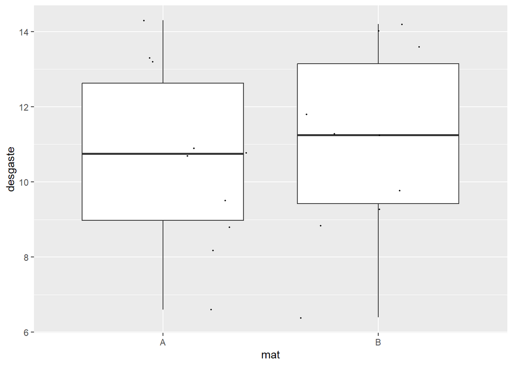

```r
set.seed(123)
ggplot(zapatos, aes(x = mat, y = desgaste)) + geom_boxplot() + geom_jitter(color="black", size=0.4, alpha=0.9)
```

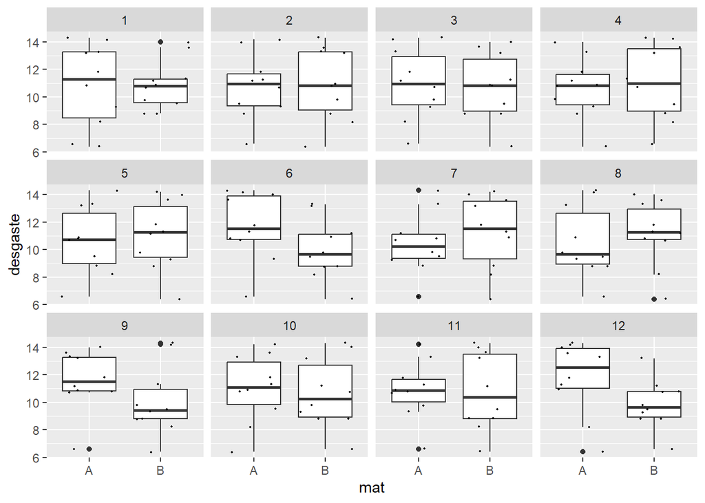

```r
perms_material <- lineup(null_permute("mat"), n = 12)
ggplot(perms_material, aes(x=mat, y = desgaste)) +  geom_boxplot() + facet_wrap(~.sample) + geom_jitter(color="black", size=0.4, alpha=0.9)
```

```r
decrypt("3Tlv DWHW gx dptgHgpx F5")
```

```
## [1] "True data in position  5"
```

2. Realiza una prueba de permutaciones para la diferencia de las medias, escribe la hipótesis nula, la hipótesis alterna y tus conclusiones.

H0 -> La diferencia de las medias es igual a 0 H1 -> La diferencia de las medias es significativamente diferente de 0

primeramente tenemos que revisar replicaciones aleatorias para ver cómo es que se distribuyen las diferencias de las medias, lo hacemos con 50,000 replicaciones.

Con lo anterior, obtenemos una distribución en la cual podemos comparar la diferencia observada del conjunto original de datos.

Nos damos cuenta que no está muy alejado de cero, por lo que no podemos rechazar la hipótesis nula. Esto es debido solamente a variación muestral y no porque realmente exista una diferencia entre materiales.

```r
set.seed(123)

dif_observada <- zapatos |>
    group_by(mat) |>
    summarize(mean_desgaste = mean(desgaste)) |>
    pivot_wider(names_from = mat, values_from = mean_desgaste) |>
    mutate(diff = B - A) |> pull(diff)

dif_observada
```

```
## [1] 0.41
```

```r
reps_material <- lineup(null_permute("mat"), zapatos, n = 50000)

reps_material <- reps_material |>
    group_by(.sample, mat) |>
    summarize(mean_desgaste = mean(desgaste)) |>
    pivot_wider(names_from = mat, values_from = mean_desgaste) |>
    mutate(diff = B - A)

percentil_obs <- ecdf(reps_material$diff)
est_dif_obs <- percentil_obs(dif_observada)
p_value1 <- 2*min(est_dif_obs, 1 - est_dif_obs)
p_value1
```

```
## [1] 0.7148
```

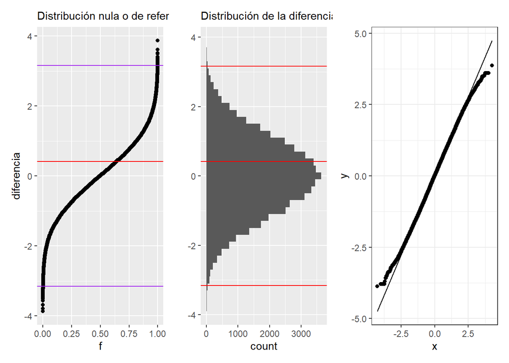

```r
greps1 <- ggplot(reps_material, aes(sample = diff)) + geom_qq(distribution = stats::qunif)  +  xlab("f") + ylab("diferencia") + labs(subtitle = "Distribución nula o de referencia") +  geom_hline(yintercept = dif_observada, colour = "red") + geom_hline(yintercept = max(reps_material$diff) - p_value1, colour = "purple") + geom_hline(yintercept = min(reps_material$diff) + p_value1, colour = "purple")

greps2 <- ggplot(reps_material, aes(x = diff)) + geom_histogram(binwidth = 0.2) +
  coord_flip() + xlab("") + labs(subtitle = "Distribución de la diferencia de medias") +  geom_vline(xintercept = dif_observada, colour = "red") + geom_vline(xintercept = min(reps_material$diff) + p_value1, colour = "red") +  geom_vline(xintercept = max(reps_material$diff) - p_value1, colour = "red")

greps3 <- ggplot(reps_material, aes(sample=diff)) + stat_qq() + stat_qq_line() + theme_bw()

greps1 + greps2 + greps3
```

3. Después de discutir con los responsables del proyecto descubrimos que nos faltaba conocer detalles del proceso generador de datos: el experimento se realizó asignando al azar un material a uno de sus zapatos y el otro material al otro zapato de cada niño. ¿Cómo incorporas esta información en tu prueba de hipótesis del inciso 2? ¿Cambian tus conclusiones?

Para responder este problema debemos parear los datos por cada uno de los niños, después calcular la diferencia y observar si esas diferencias están dentro de los rangos de la distribución.

Para obtener la distribución calculamos la desviación estándar de las diferencias de las medias de los datos originales. Con esto dibujamos la media.

Para después incorporar los datos de los niños y observar si esas diferencias están dentro de los rangos de la distribución.

Podemos observar que están muy cercanos al promedio y es poca la evidencia en contra de la hipótesis nula.

También observamos que entre los niños hay una diferencia considerable, esto puede causar que tengamos la impresión de que sí existen diferencias entre materiales cuando no se toman en cuenta los niños. En cambio, al tomar los niños, vemos que existen diferencias entre ellos que también se distribuyen normalmente y se encuentran dentro del rango de las diferencias de las medias.

Hice un diagrama de caja para observar cómo se distribuyen las diferencias y observamos que la mediana está muy cercana a la diferencia observada.

Al observar los conjuntos de datos vemos que son idénticos y solamente estamos añadiendo la columna de los niños, por lo que podemos concluir que no hay diferencias entre los materiales pero sí entre los niños. Recordemos que las medias son sensibles a atípicos.

```r
std_reps <- reps_material$diff |> sd()
std_reps
```

```
## [1] 1.089126
```

```r
zapatos2 <- read_csv("datos/zapatos-2.csv")
zapatos2 <- zapatos2 |> mutate(kid=as.character(`niño`)) |> mutate(mat = case_when(material == 1 ~ "A", material == 2 ~ "B")) |> select(-material,-`niño`) |> pivot_wider(names_from = mat, values_from = desgaste) |> mutate(diff = B - A)
zapatos2
```

```
## # A tibble: 10 × 4
##    kid       A     B   diff
##    <chr> <dbl> <dbl>  <dbl>
##  1 1      13.2  14    0.800
##  2 2       8.2   8.8  0.600
##  3 3      10.9  11.2  0.300
##  4 4      14.3  14.2 -0.100
##  5 5      10.7  11.8  1.10
##  6 6       6.6   6.4 -0.200
##  7 7       9.5   9.8  0.300
##  8 8      10.8  11.3  0.5
##  9 9       8.8   9.3  0.5
## 10 10     13.3  13.6  0.300
```

```r
dif_obs_z2_mean_A <- zapatos2 |> summarize(mean(A)) |> pull()
dif_obs_z2_mean_B <- zapatos2 |> summarize(mean(B)) |> pull()
dif_obs_z2_mean <- dif_obs_z2_mean_B - dif_obs_z2_mean_A
dif_obs_z2_mean
```

```
## [1] 0.41
```

```r
mean(zapatos2$diff)
```

```
## [1] 0.41
```

```r
dif_observada - dif_obs_z2_mean
```

```
## [1] 0
```

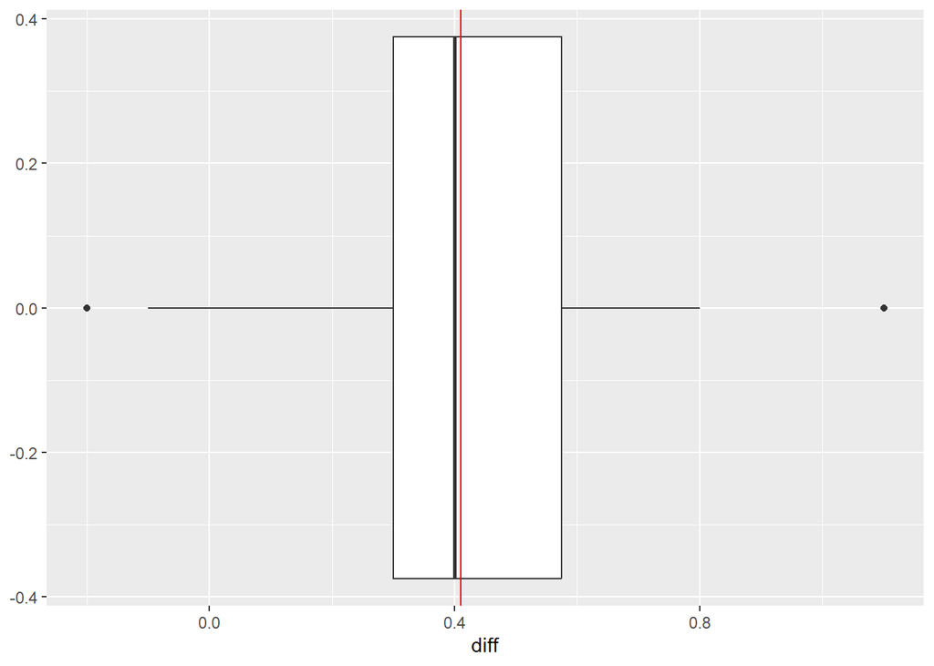

```r
ggplot(zapatos2, aes(y=diff)) + geom_boxplot() + coord_flip() + geom_hline(yintercept = dif_obs_z2_mean, colour = "red")
```

```r
rep_zapatos2 <- lineup(null_permute("kid"), zapatos2, n = 50000)

rep_zapatos2_histogram <- rep_zapatos2 |> group_by(diff) |> summarize(n = n()) |> mutate(freq = n / sum(n))

rep_zapatos2_histogram
```

```
## # A tibble: 8 × 3
##     diff      n  freq
##    <dbl>  <int> <dbl>
## 1 -0.200  50000   0.1
## 2 -0.100  50000   0.1
## 3  0.300 100000   0.2
## 4  0.300  50000   0.1
## 5  0.5   100000   0.2
## 6  0.600  50000   0.1
## 7  0.800  50000   0.1
## 8  1.10   50000   0.1
```

```r
std_z2_diff <- rep_zapatos2_histogram$diff |> sd()
std_z2_diff
```

```
## [1] 0.435685
```

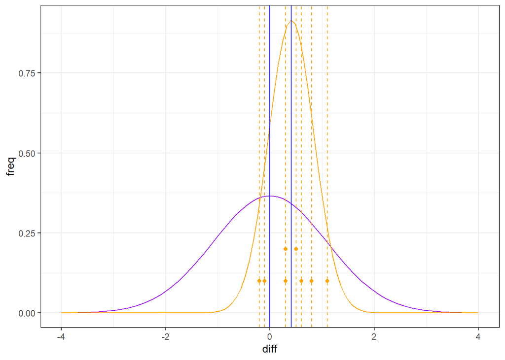

```r
z2_g1 <- ggplot() + geom_histogram() + geom_function(fun = dnorm, colour = "purple", args = list(mean = 0, sd = std_reps)) + xlim(-4, 4) + geom_vline(xintercept = zapatos2$diff, colour = "orange", linetype = "dashed") + geom_point(data = rep_zapatos2_histogram, mapping = aes(x = diff, y = freq), color = "orange", size = 1.5) + theme_bw() + geom_function(fun = dnorm, colour = "orange", args = list(mean = dif_observada, sd = std_z2_diff)) + geom_vline(xintercept = 0, colour = "blue") + geom_vline(xintercept = dif_observada, colour = "blue")

z2_g1
```

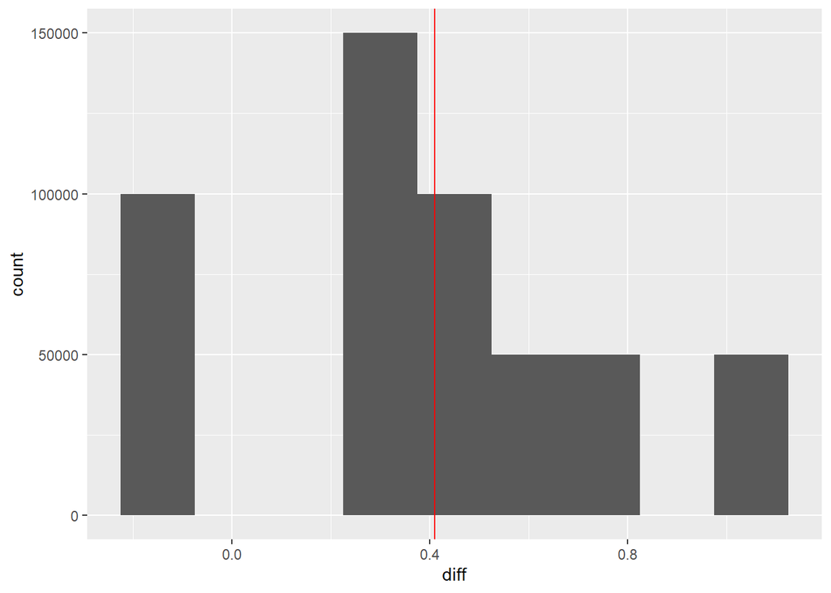

```r
ggplot(rep_zapatos2, aes(x=diff)) + geom_histogram(binwidth = 0.15) + geom_vline(xintercept = dif_observada, colour = "red")
```

```r
z1 <- read_csv("datos/zapatos-1.csv")
z2 <- read_csv("datos/zapatos-2.csv")
```

Por otro lado al revisar con mis compañero de examen, me propone otro método en el cual permutemos los zapatos entre los niños, pues se supone que no debe existir diferencia.

entonces aplicamos permutaciones por niño y después calculamos la media por cada muestra de los A y de los B, después calculamos la diferencia y graficamos.

Vemos en esta nueva distribución que la diferencia observada está muy distante, con lo cual pareciera ser que hay evidencia.

Sin embargo, no me convence este método, ya que al estar intercambiando las etiquetas a nivel de niño y luego generar promedios de a y b estamos generando una nueva distribución que tiende a cero, causando que el 0.41 que habíamos obtenido se vea sumamente grande cuando en esta nueva distribución la diferencia es de 0.0055.

Por otro lado, al comparar el pvalue, sigue estando distante, aunque poco probable sigue estando dentro de la distribución.

En lo personal siento que esta distribución nos está mostrando cómo es que el valor tiende a cero y que la distribución nueva tiene colas cortas. Un valor de 0.41 es muy grande en esta distribución, pero esta distribución está tendiendo a cero porque nosotros lo causamos al permutar los datos en lugar de permitar los niños.

No obstante, hace sentido hacerlo así, cuando se tomaba sin niños no tenemos los datos pareados, cuanod incluimos la variable niños entonces ya tenemos los datos por pares y esto causa que ambos materiales sean evaluados en las mismas circunstancias del niño.

```r
set.seed(123)

zap2 <- read_csv("datos/zapatos-2.csv")

zap2 <- zap2 |> mutate(kid=as.character(`niño`)) |> mutate(mat = case_when(material == 1 ~ "A", material == 2 ~ "B")) |> select(-material,-`niño`)

zap2  <- zap2 |> group_split(kid) |> map_df(~lineup(null_permute("mat"), .x, n = 1000)) |> group_by(mat, .sample) |> summarize(mdesgaste = mean(desgaste)) |> group_by(.sample) |> arrange(.sample, mat)  |> summarise(dif_media_desgaste = diff(mdesgaste))

percentil_obs_2 <- ecdf(zap2$dif_media_desgaste)
est_dif_obs_2 <- percentil_obs_2(dif_observada)
p_value2 <- 2*min(est_dif_obs_2, 1 - est_dif_obs_2)
p_value2
```

```
## [1] 0.016
```

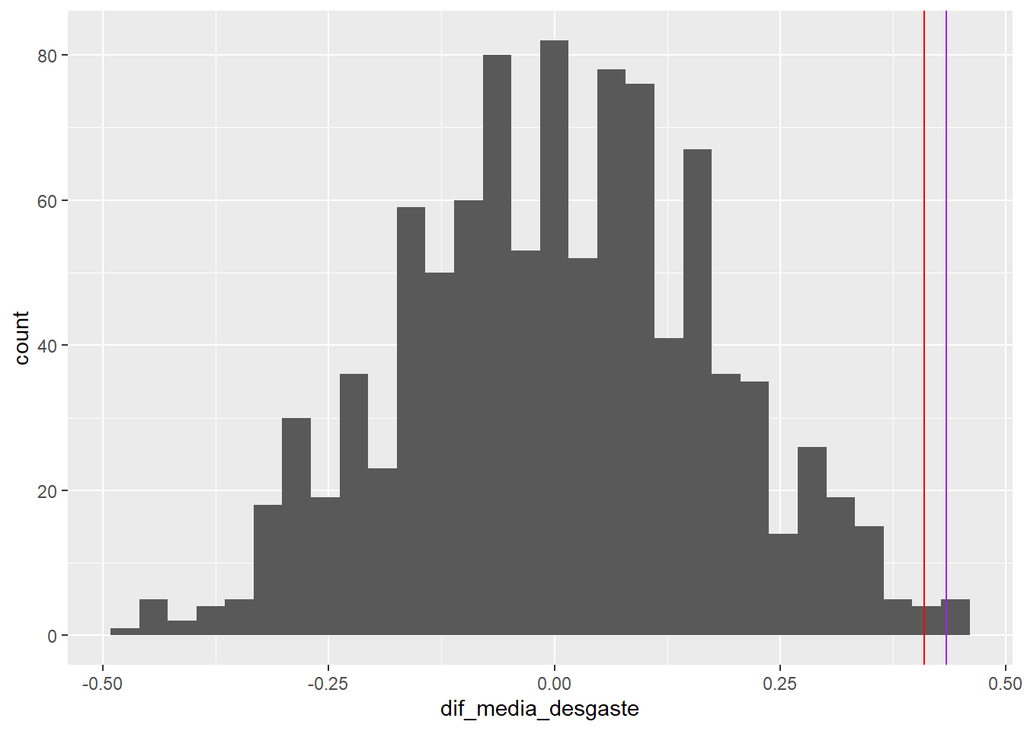

```r
ggplot(zap2, aes(x=dif_media_desgaste)) + geom_histogram() + geom_vline(xintercept = dif_observada, colour = "red") + geom_vline(xintercept = max(zap2$dif_media_desgaste)-p_value2, colour = "purple")
```

## Bootstrap

#### Antecedentes

En México, las elecciones tienen lugar un domingo, los resultados oficiales del proceso se presentan a la población una semana después. A fin de evitar proclamaciones de victoria injustificadas durante ese periodo el INE organiza un conteo rápido. Un conteo rápido es un procedimiento para estimar, a partir de una muestra aleatoria de casillas, el porcentaje de votos a favor de cada opción en la boleta.

En 2021 se realizó un conteo rápido para estimar los resultados de la [consulta popular 2021](https://ine.mx/conteo-rapido-consulta-popular-2021/) y en los siguientes incisos estimarán los resultados de la consulta y evaluarán la metodología.

##### Diseño de la muestra

El diseño utilizado en los conteos rápidos es *muestreo estratificado simple*, es decir:

1. se particionan las casillas de la población en estratos (cada casilla pertenece a exactamente un estrato), y
2. dentro de cada estrato se usa *muestreo aleatorio* para seleccionar las casillas que estarán en la muestra.

##### Estimación

Una de las metodologías de estimación, que se usa en el conteo rápido (tanto de elecciones como en consultas) es *estimador de razón combinado*, con intervalos de 95% de confianza construidos con el método normal y error estándar bootstrap. En este ejercicio debes construir intervalos usando este procedimiento.

Para cada opción en la consulta (sí/no/nulos) usarás la muestra del conteo rápido para estimar los resultados de la consulta.

1. Calcula el estimador de razón combinado, para muestreo estratificado la fórmula es:

$$\hat{p}=\frac{\sum_h \frac{N_h}{n_h}
\sum_i Y_{hi}}{\sum_h \frac{N_h}{n_h} \sum_i X_{hi}}$$
donde:

- $\hat{p}$ es la estimación de la proporción de votos que recibió la opción (ej: *sí*).
- $Y_{hi}$ es el número total de votos que recibió *la opción* (ej: *sí*) en la $i$-ésima casillas, que pertence al $h$-ésimo estrato.
- $X_{hi}$ es el número total de votos en la $i$-ésima casilla, que pertence al $h$-ésimo estrato.
- $N_h$ es el número total de casillas en el $h$-ésimo estrato.
- $n_h$ es el número de casillas del $h$-ésimo estrato que se seleccionaron en la muestra.

##### Datos

Necesitarás los siguientes datos:

- Cómputos [aquí](https://computos.cp2021.ine.mx/votos-distrito/mapa)
- Muestra del conteo rápido usada en la estimación [aquí](https://ine.mx/conteo-rapido-consulta-popular-2021/)

```r
# preprocesamiento de tablas de datos
computos <- read_delim("datos/20210802-2130_INE-CONSULTA-POPULAR-2021/20210802-2130_COMPUTOS-INE-CP2021.csv",
    delim = "|", escape_double = FALSE, trim_ws = TRUE, quote = "\'",
    skip = 5)
computos <- computos |>
  rename(ID = CLAVE_MRCP) |>
  mutate(ESTRATO = str_c(str_pad(ID_ENTIDAD, 2, pad = "0"),
                         str_pad(ID_DISTRITO_FEDERAL, 2, pad = "0")),
         LISTA_NOMINAL = LISTA_NOMINAL_MRCP,
         TOTAL = TOTAL_OPINIONES)

muestra <- read_delim("https://ine.mx/wp-content/uploads/2021/08/Conteos-ConsPop21-Lista-MuestraCalculo.txt", delim = "|", skip = 1)
muestra_tidy <- muestra |>
  mutate(
    ID_ESTADO = str_pad(ID_ESTADO, 2, pad = "0"),
    SECCION = str_pad(SECCION, 4, pad = "0"),
    ID_CASILLA = str_pad(ID_CASILLA, 2, pad = "0"),
    ID = str_c(ID_ESTADO, SECCION, TIPO_CASILLA, ID_CASILLA)
    ) |>
  group_by(ESTRATO) |>
  mutate(n = n()) |>
  ungroup()
```

2. Utiliza **bootstrap** para calcular el error estándar, y reporta tu estimación del error.
   - Genera 1000 muestras bootstrap.
   - Recuerda que las muestras bootstrap tienen que tomar en cuenta la metodología que se utilizó en la selección de la muestra original, en este caso implica que para cada remuestra debes tomar muestra aleatoria independiente dentro de cada estrato.
3. Construye un intervalo del 95% de confianza utilizando el método normal. Revisa si el supuesto de normalidad es razonable.
4. Reporta tus intervalos en una tabla. Compara la longitud de los 3 intervalos y describe que observas.
5. ¿Tus intervalos contienen los valores observados en los cómputos? Explica los resultados observados.

#### Calibración

Selecciona al menos 50 muestras del mismo tamaño y con el mismo diseño que la muestra utilizada en el conteo rápido. Esto es, selecciona el mismo número de casillas, usando muestreo aleatorio simple dentro de cada estrato.

- Para cada muestra calcula un intervalo del 95% de confianza usando bootstrap.
- Grafica los intervalos y calcula la proporción de ellos que contienen el verdadero valor observado. Describe tus observaciones y compara con el intervalo obtenido en el ejercicio anterior.

#### Análisis Exploratorio

Un voto nulo corresponde a una boleta donde el ciudadano acudió a las urnas y anuló su voto.

Antes de contestar los siguiente incisos piensen que rango esperarían ver para la proporción de votos nulos en una casilla.

- Describe la distribución de datos nulos en la muestra, y como se relaciona con el total de votos, realiza gráficas y describe tus observaciones.
- En la distribución de proporción de nulos se observan datos atípicos, ¿cuál crees que sea la razón de estas observaciones extremas? ¿consideras que se deben eliminar de la muestra antes de realizar la estimación?